# ФББ - R - Домашнее задание №10

Данил Сидиков

15 12 2023

# Подгрузка пакетов

```r
library("hexSticker") #загрузим установленный пакет в текущую R сессию
library(caret)
```

```r
library(corrplot)
library(ggplot2)
library(ggpubr)
library(tidymodels)
library('tidyverse')
library(moments)
library(gridExtra)
library(datarium)
```

# Задание №1

> Выберите свою любую любимую картинку в рамках приличия.

> Используя пакет hexSticker, нарисуйте шестиугольный логотип.

[figure not shown]

```r
s <- sticker("flag.jpg", package="hexSticker", p_size=20, s_x=1, s_y=.75, s_width=.6, h_fill="#f9690e", h_color="#f39c12", filename="/flag.jpg")

print(s)
```

# Задание №2

> Воспользуйтесь данными mtcars.

> Каждая из 32 машин охарактеризована 11ю показателями.

> Скоррелируйте показатели машин друг с другом. Выделите высокоскоррелированные показатели: коэффициент корреляции Спирмена > 0.8 без учета значимости. Оставьте только такие показатели, которые не являются высокоскоррелированными между собой согласно вышеописанным критериям (из группы должен остаться любой один).

> Визуализируйте кореляционные матрицы до и после фильтрации так, чтобы были видны в явном виде значения коэффициентов корреляции.

> (3*) Выделите на рисунке, построенном по исходной матрице корреляций, значения, которые подлежат фильтрации.

> На основании оставшихся показателей скоррелируйте машины друг с другом. Визуализируйте получившуюся корреляционную матрицу, указав только значимые коэффициенты корреляции любым способом (звездочки, значения коэффициентов корреляции, цвет или что-то другое на ваш вкус).

> Измените палитру на любую НЕ красно-синюю.

```r
data(mtcars)
head(mtcars)
```

```
##                    mpg cyl disp  hp drat    wt  qsec vs am gear carb
## Mazda RX4         21.0   6  160 110 3.90 2.620 16.46  0  1    4    4
## Mazda RX4 Wag     21.0   6  160 110 3.90 2.875 17.02  0  1    4    4
## Datsun 710        22.8   4  108  93 3.85 2.320 18.61  1  1    4    1
## Hornet 4 Drive    21.4   6  258 110 3.08 3.215 19.44  1  0    3    1
## Hornet Sportabout 18.7   8  360 175 3.15 3.440 17.02  0  0    3    2
## Valiant           18.1   6  225 105 2.76 3.460 20.22  1  0    3    1
```

```r
# Вычисление матрицы корреляции
cormt <- cor(mtcars, method = "spearman")
round(cormt,2)
```

```
##        mpg   cyl  disp    hp  drat    wt  qsec    vs    am  gear  carb
## mpg   1.00 -0.91 -0.91 -0.89  0.65 -0.89  0.47  0.71  0.56  0.54 -0.66
## cyl  -0.91  1.00  0.93  0.90 -0.68  0.86 -0.57 -0.81 -0.52 -0.56  0.58
## disp -0.91  0.93  1.00  0.85 -0.68  0.90 -0.46 -0.72 -0.62 -0.59  0.54
## hp   -0.89  0.90  0.85  1.00 -0.52  0.77 -0.67 -0.75 -0.36 -0.33  0.73
## drat  0.65 -0.68 -0.68 -0.52  1.00 -0.75  0.09  0.45  0.69  0.74 -0.13
## wt   -0.89  0.86  0.90  0.77 -0.75  1.00 -0.23 -0.59 -0.74 -0.68  0.50
## qsec  0.47 -0.57 -0.46 -0.67  0.09 -0.23  1.00  0.79 -0.20 -0.15 -0.66
## vs    0.71 -0.81 -0.72 -0.75  0.45 -0.59  0.79  1.00  0.17  0.28 -0.63
## am    0.56 -0.52 -0.62 -0.36  0.69 -0.74 -0.20  0.17  1.00  0.81 -0.06
## gear  0.54 -0.56 -0.59 -0.33  0.74 -0.68 -0.15  0.28  0.81  1.00  0.11
## carb -0.66  0.58  0.54  0.73 -0.13  0.50 -0.66 -0.63 -0.06  0.11  1.00
```

```r
# Выделение пар переменных с корреляцией > 0.8
high_corr <- which(abs(cormt) > 0.8 & cormt != 1 & row(cormt) != col(cormt), arr.ind = TRUE)

# Вывод высокоскоррелированных переменных
high_corr_pairs <- data.frame(Variable1 = colnames(cormt)[high_corr[,1]],
                            Variable2 = colnames(cormt)[high_corr[,2]],
                            Correlation = cormt[high_corr])
head(high_corr_pairs)
```

```
##   Variable1 Variable2 Correlation
## 1       cyl       mpg  -0.9108013
## 2      disp       mpg  -0.9088824
## 3        hp       mpg  -0.8946646
## 4        wt       mpg  -0.8864220
## 5       mpg       cyl  -0.9108013
## 6      disp       cyl   0.9276516
```

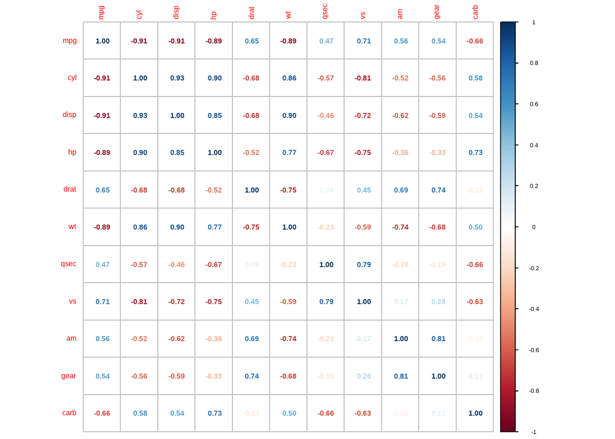

```r
#ДО
corrplot(cormt, method="number")
```

```r
# Создание рецепта
rec <- recipe(mpg ~ ., data = mtcars)

# Применение шага корреляции
corr_filter <- rec %>%
 step_corr(all_numeric_predictors(), threshold = .8)

# Подготовка данных
filter_obj <- prep(corr_filter, training = mtcars)

# Применение фильтра к тестовым данным
filtered_data <- bake(filter_obj, mtcars)

cormt <- cor(filtered_data, method = "spearman")
round(cormt,2)
```

```
##         hp  drat    wt  qsec    vs    am  gear  carb   mpg
## hp    1.00 -0.52  0.77 -0.67 -0.75 -0.36 -0.33  0.73 -0.89
## drat -0.52  1.00 -0.75  0.09  0.45  0.69  0.74 -0.13  0.65
## wt    0.77 -0.75  1.00 -0.23 -0.59 -0.74 -0.68  0.50 -0.89
## qsec -0.67  0.09 -0.23  1.00  0.79 -0.20 -0.15 -0.66  0.47
## vs   -0.75  0.45 -0.59  0.79  1.00  0.17  0.28 -0.63  0.71
## am   -0.36  0.69 -0.74 -0.20  0.17  1.00  0.81 -0.06  0.56
## gear -0.33  0.74 -0.68 -0.15  0.28  0.81  1.00  0.11  0.54
## carb  0.73 -0.13  0.50 -0.66 -0.63 -0.06  0.11  1.00 -0.66
## mpg  -0.89  0.65 -0.89  0.47  0.71  0.56  0.54 -0.66  1.00
```

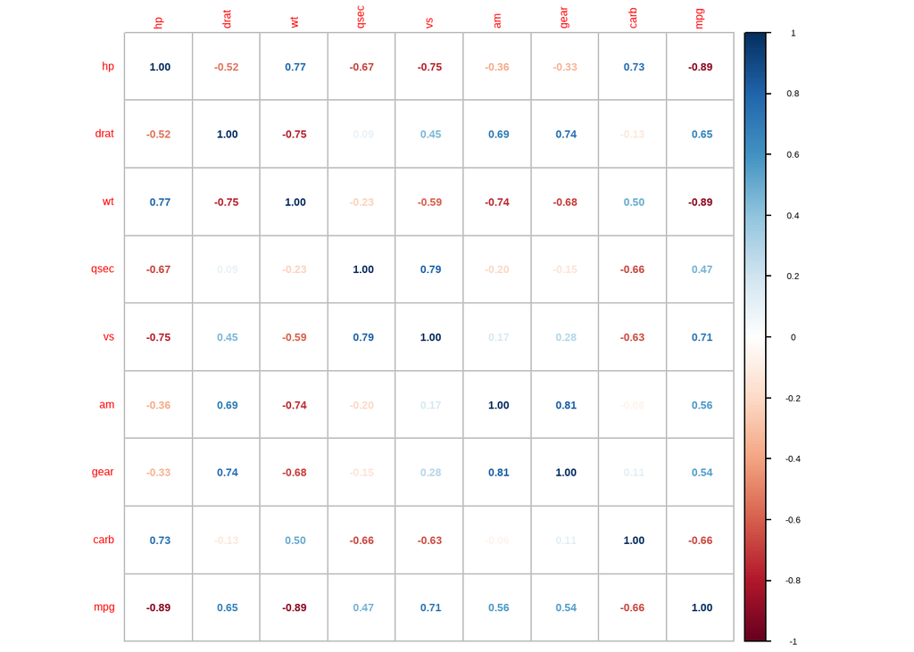

```r
corrplot(cormt, method="number")
```

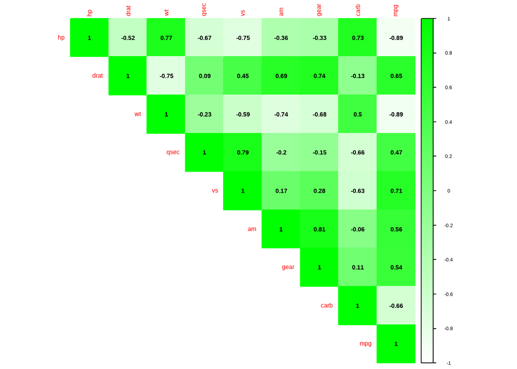

```r
# Вычисление матрицы корреляции для отфильтрованных данных
cormt_filtered <- cor(filtered_data, method = "spearman")

# Определение новой палитры цветов
my_palette <- colorRampPalette(c("white", "green"))

# Визуализация матрицы корреляций с новой палитрой цветов
corrplot(cormt_filtered, method="color", col=my_palette(200), type="upper", addCoef.col = "black", sig.level = 0.05)
```

# Задание №3

> Для каждого численного параметра из данных про ирисы (iris) (должно получиться 4 параметра) нарисуйте график, состоящий из двух графиков, расположенных рядом: qqplot и гистограмма (на гистограме подписаны текстом значения асимметрии и эксцесса).

> В итоге должно получиться 4 графика, каждый из которых составлен из двух графиков.

> Подпишите все оси, графики, название параметров и пр.

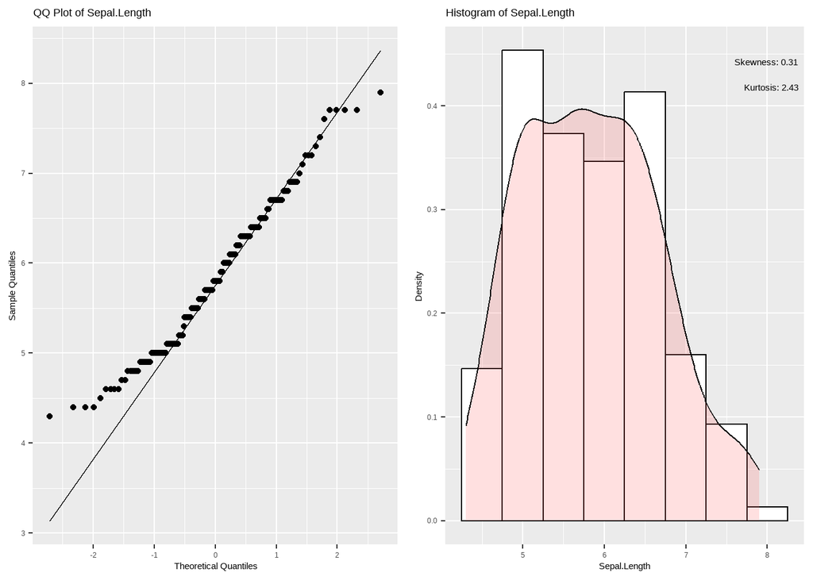

```r
# Define a function to create plots for each parameter
create_plots <- function(data, param) {
  # Calculate skewness and kurtosis
  skewness <- skewness(data[[param]])
  kurtosis <- kurtosis(data[[param]])

  # Create a QQ plot
  qq_plot <- ggplot(data, aes(sample = .data[[param]])) +
    geom_qq() +
    geom_qq_line() +
    labs(title = paste("QQ Plot of", param),
         x = "Theoretical Quantiles",
         y = "Sample Quantiles")

  # Create a histogram
  hist_plot <- ggplot(data, aes(x = .data[[param]])) +
    geom_histogram(aes(y = ..density..), binwidth = 0.5, colour = "black", fill = "white") +
    geom_density(alpha = .2, fill = "#FF6666") +
    labs(title = paste("Histogram of", param),
         x = param,
         y = "Density") +
    annotate("text", x = Inf, y = Inf,
             label = paste("Skewness:", round(skewness, 2), "\nKurtosis:", round(kurtosis, 2)),
             hjust = 1.1, vjust = 2)

  # Combine the plots
  combined_plot <- grid.arrange(qq_plot, hist_plot, ncol=2)

  return(combined_plot)
}

# Use the function for each parameter
create_plots(iris, "Sepal.Length")
```

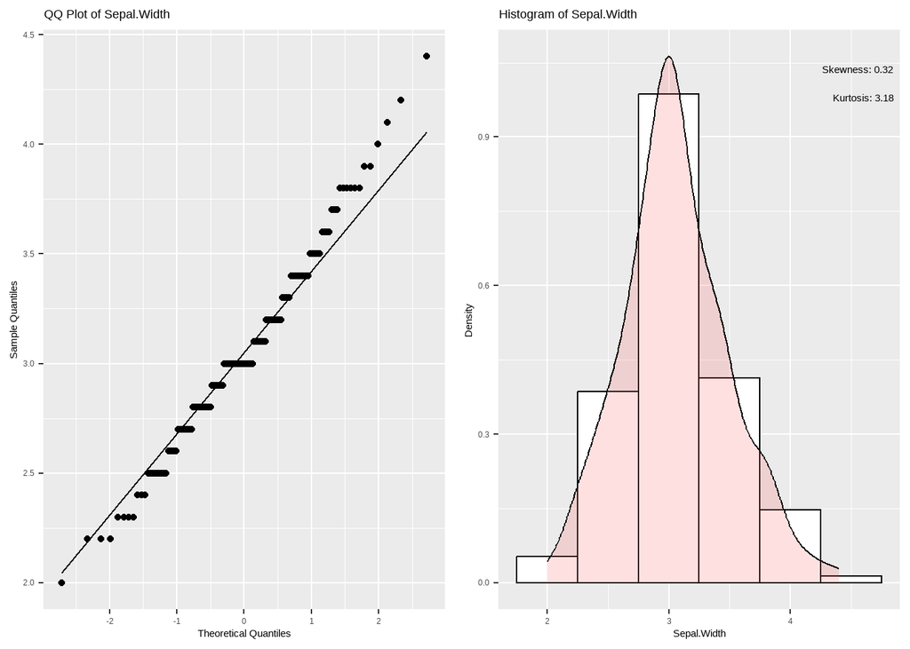

```r
create_plots(iris, "Sepal.Width")
```

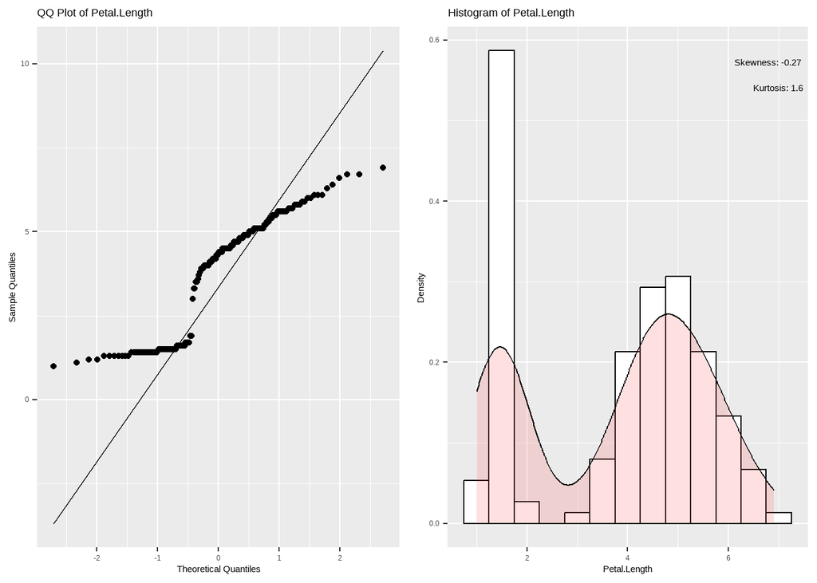

```r
create_plots(iris, "Petal.Length")
```

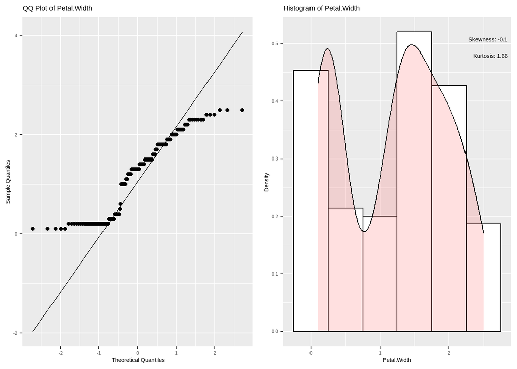

```r
create_plots(iris, "Petal.Width")
```

# Задание №4

> Воспользуйтесь данными mice из пакета datarium.

> Узнайте, отличается ли средний вес мышей от 25г?

> Не забудьте сформулировать нулевую и альтернативную гипотезы, задать уровень значимости, вывести и p-value и сделать вывод.

```r
print("Нулевая гипотеза: средний вес мышей не отличается от 25г")
```

```
## [1] "Нулевая гипотеза: средний вес мышей не отличается от 25г"
```

```r
print("Уровень значимости: 0.05")
```

```
## [1] "Уровень значимости: 0.05"
```

```r
# Загрузка данных
data("mice")

# Просмотр структуры данных
head(as.data.frame(mice))
```

```
##   name weight
## 1  M_1   18.9
## 2  M_2   19.5
## 3  M_3   23.1
## 4  M_4   20.1
## 5  M_5   20.3
## 6  M_6   23.4
```

```r
# Выполняем t-тест
t_test_result <- t.test(mice$weight, mu = 25)

# Выводим результаты t-теста
print(t_test_result)
```

```
##
##  One Sample t-test
##
## data:  mice$weight
## t = -8.1045, df = 9, p-value = 1.995e-05
## alternative hypothesis: true mean is not equal to 25
## 95 percent confidence interval:
##  18.78346 21.49654
## sample estimates:
## mean of x
##     20.14
```

```r
# Проверяем p-value
if (t_test_result$p.value < 0.05) {
  print("Отвергаем нулевую гипотезу, средний вес мышей отличается от 25г")
} else {
  print("Не отвергаем нулевую гипотезу, средний вес мышей не отличается от 25г")
}
```

```
## [1] "Отвергаем нулевую гипотезу, средний вес мышей отличается от 25г"
```

# Задание №5

> Сформулируйте задачу №4 так, чтобы выяснить в какую сторону от 25г в среднем отличается вес мышей из предложенной выборки.

```r
#Нулевая гипотеза (H0): Средний вес мышей равен 25г.
#Альтернативная гипотеза (H1): Средний вес мышей больше или меньше 25г.

# Выполняем t-тест
t_test_result <- t.test(mice$weight, mu = 25)

# Выводим результаты t-теста
print(t_test_result)
```

```
##
##  One Sample t-test
##
## data:  mice$weight
## t = -8.1045, df = 9, p-value = 1.995e-05
## alternative hypothesis: true mean is not equal to 25
## 95 percent confidence interval:
##  18.78346 21.49654
## sample estimates:
## mean of x
##     20.14
```

```r
#Если это значение положительно, это означает, что среднее значение выборки больше, чем предполагаемое среднее (25г в данном случае). Если значение t-статистики отрицательно, это означает, что среднее значение выборки меньше предполагаемого среднего.

# Определяем, в какую сторону отличается средний вес
if (t_test_result$statistic > 0) {
  print("Средний вес мышей больше 25г")
} else {
  print("Средний вес мышей меньше 25г")
}
```

```
## [1] "Средний вес мышей меньше 25г"
```

# Задание №6

> Воспользуйтесь набором данных genderweight из пакета datarium.

> Различается ли в среднем вес мужчин и женщин из предложенной выборки?

> Объясните выбор теста, сформулируйте необходимые нулевую и альтернативную гипотезы.

> Визуализируйте результаты наиболее наглядным образом.

```r
data("genderweight")
#Нулевая гипотеза (H0) для двухвыборочного t-теста гласит, что средние двух групп равны. Альтернативная гипотеза (H1) утверждает, что средние значимо различаются.
#Для этого можно использовать двухвыборочный t-тест, который предназначен для сравнения средних двух независимых групп.
t.test(weight ~ group, data = genderweight)
```

```
##
##  Welch Two Sample t-test
##
## data:  weight by group
## t = -20.791, df = 26.872, p-value < 2.2e-16
## alternative hypothesis: true difference in means between group F and group M is not equal to 0
## 95 percent confidence interval:
##  -24.53135 -20.12353
## sample estimates:
## mean in group F mean in group M
##        63.49867        85.82612
```

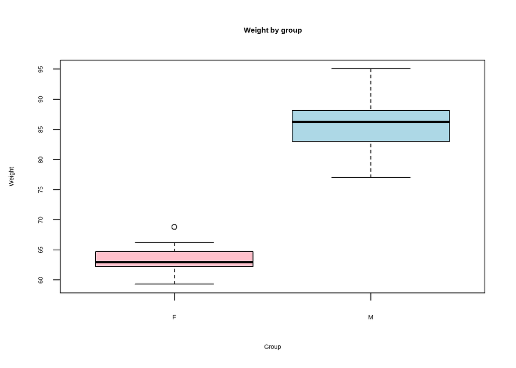

```r
boxplot(weight ~ group, data = genderweight,
        xlab = "Group", ylab = "Weight",
        main = "Weight by group",
        col = c("pink","lightblue"))
```

# Задание №7

> Воспользуйтесь набором данных mices2 из пакета datarium.

> Изменился ли в среднем вес мышей после воздействия?

> Если изменился, то уменьшился или увеличился?

```r
data(mice2)

# Проведение t-теста
t_test_result <- t.test(mice2$before, mice2$after)

# Вывод результатов
print(t_test_result)
```

```
##
##  Welch Two Sample t-test
##
## data:  mice2$before and mice2$after
## t = -17.453, df = 15.667, p-value = 1.099e-11
## alternative hypothesis: true difference in means is not equal to 0
## 95 percent confidence interval:
##  -223.7515 -175.2085
## sample estimates:
## mean of x mean of y
##    200.56    400.04
```

```r
# Определяем, в какую сторону отличается средний вес
if (t_test_result$statistic > 0) {
  print("Средний вес мышей увеличился")
} else {
  print("Средний вес мышей уменьшился")
}
```

[output not shown]

> Результат t-теста будет содержать статистическую значимость (p-value), которая позволит определить, произошло ли значимое изменение в среднем весе мышей. Если p-value меньше заданного уровня значимости (обычно 0.05), то можно заключить, что изменение веса мышей после воздействия статистически значимо.

# Задание №8

> Воспользуйтесь набором данных о звездных войнах.

> Разделите персонажей на высоких (рост (height) > 180) и невысоких (рост <= 180).

> Связаны ли рост и гендер (gender) персонажей?

```r
data(starwars)

# Разделение персонажей на высоких и невысоких
high_characters <- filter(starwars, height > 180)
low_characters <- filter(starwars, height <= 180)

# Преобразование фактора 'gender' в символьный вектор
starwars$gender <- as.character(starwars$gender)

# Создание вектора с новыми уровнями
new_levels <- c("masculine" = 1, "feminine" = 2)

# Преобразование символьного вектора 'gender' в числовой вектор
starwars$gender <- as.numeric(new_levels[starwars$gender])


# Вычисление корреляции между ростом и гендером
cor_result <- cor.test(starwars$height, starwars$gender)

# Вывод результатов
print(cor_result)
```

```
##
##  Pearson's product-moment correlation
##
## data:  starwars$height and starwars$gender
## t = -0.976, df = 75, p-value = 0.3322
## alternative hypothesis: true correlation is not equal to 0
## 95 percent confidence interval:
##  -0.3277479  0.1148700
## sample estimates:
##        cor
## -0.1119901
```

```r
# Проверяем p-value
if (cor_result$p.value < 0.05) {
  print("существует статистически значимая связь между ростом и гендером персонажей")
} else {
  print("Не существует статистически значимая связь между ростом и гендером персонажей")
}
```

```
## [1] "Не существует статистически значимая связь между ростом и гендером персонажей"
```

> Результат корреляционного теста будет содержать значение корреляции и p-value. Если p-value меньше заданного уровня значимости (обычно 0.05), то можно заключить, что существует статистически значимая связь между ростом и гендером персонажей.

# Задание №9

> Воспользуйтесь данными из таблицы pois.tsv

> Различается ли в среднем время (time) между группами poison? Воспользуйтесь ANOVA.

> Если различается, то между какими конкретно группами?

```r
# Загрузка данных
data <- read.delim("pois.tsv", sep = "\t")

# Разделение строки на колонки
data <- data.frame(do.call("rbind", strsplit(as.character(data$N.time.poison.treat), ",")))

# Переименование колонок
names(data) <- c("N", "time", "poison", "treat")

# Преобразование типов данных
data$N <- as.integer(data$N)
data$time <- as.numeric(data$time)
data$poison <- as.factor(data$poison)
data$treat <- as.factor(data$treat)

# Создание модели ANOVA
model <- aov(time ~ poison, data = data)

# Получение результатов ANOVA
results <- summary(model)

# Вывод результатов
print(results)
```

```
##             Df Sum Sq Mean Sq F value   Pr(>F)
## poison       2  1.033  0.5165   11.79 7.66e-05 ***
## Residuals   45  1.972  0.0438
## ---
## Signif. codes:  0 '***' 0.001 '**' 0.01 '*' 0.05 '.' 0.1 ' ' 1
```

```r
#Результаты ANOVA будут показаны в консоли. Если p-значение для группы poison меньше 0.05, это указывает на то, что существуют значимые различия в среднем времени между группами.

# Выполнение Tukey HSD
posthoc <- TukeyHSD(model)

# Вывод результатов
print(posthoc)
```

```
##   Tukey multiple comparisons of means
##     95% family-wise confidence level
##
## Fit: aov(formula = time ~ poison, data = data)
##
## $poison
##          diff        lwr         upr     p adj
## 2-1 -0.073125 -0.2525046  0.10625464 0.5881654
## 3-1 -0.341250 -0.5206296 -0.16187036 0.0000971
## 3-2 -0.268125 -0.4475046 -0.08874536 0.0020924
```

> Если p-значение для пары групп меньше 0.05, это указывает на то, что эти две группы отличаются друг от друга

# Задание №10

> Воспользуйтесь данными из таблицы pois.tsv

> Различаются ли в среднем времена отклика между каждой группой по столбцу treat? Проведите необходимое количество сравнений.

> Для решения воспользуйтесь непараметрическим тестом. Укажите допущения, если необходимо.

> Создайте таблицу, где в строках будут указаны пары сравниваемых групп, для каждого сравнения укажите p-value.

> С помощью функции p.adj дополните таблицу поправленными p-value, используйте два любых разных способа поправки, принадлежащих к разным классам (FDR, FWER).

> Нарисуйте диаграмму рассеяния, где по осям будут отложены значения поправленных p-value для одного из методов.

> Сделайте вывод о том, какой из методов “строже” и почему.

```r
#Проведение непараметрического теста Краскела-Уоллиса для сравнения средних значений времени отклика в разных группах из столбца 'treat'. Этот тест используется в случае, когда данные не подчиняются нормальному распределению. В R для этого используется функция kruskal.test

kruskal_results <- kruskal.test(time ~ treat, data = data)

#Создание таблицы p-value для каждой пары групп
pairwise_results <- pairwise.wilcox.test(data$time, data$treat, p.adjust.method = "none")
```

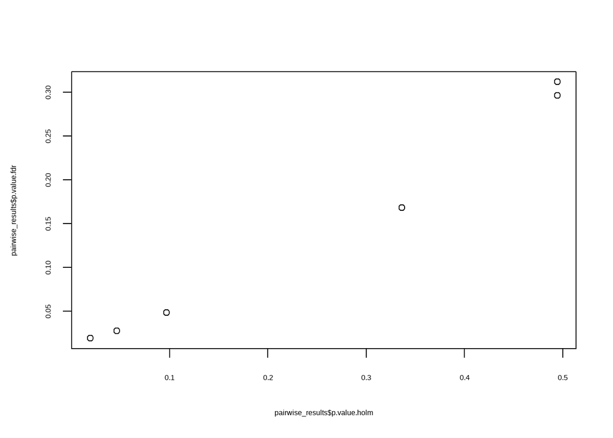

```r
#Корректировка p-value с использованием функции p.adjust.Например, можно использовать методы "holm" (FWER) и "fdr" (FDR)
pairwise_results$p.value.holm <- p.adjust(pairwise_results$p.value, method = "holm")
pairwise_results$p.value.fdr <- p.adjust(pairwise_results$p.value, method = "fdr")

#Построение диаграммы рассеяния для значений поправленных p-value
plot(pairwise_results$p.value.holm, pairwise_results$p.value.fdr)
```

> Если после коррекции p-value увеличиваются, это указывает на то, что примененный метод коррекции “строже”